# Homework_12

Luke Daniels

4/11/2018

For this ggplot demonstration, I will be using the R data set “USarrest”. Here is the structure:

```r
library(ggplot2)
library(patchwork)
library(maps)
library(readxl)
library(openxlsx)
head(USArrests)
```

```
##            Murder Assault UrbanPop Rape
## Alabama      13.2     236       58 21.2
## Alaska       10.0     263       48 44.5
## Arizona       8.1     294       80 31.0
## Arkansas      8.8     190       50 19.5
## California    9.0     276       91 40.6
## Colorado      7.9     204       78 38.7
```

As we can see this is state / location data. It would be nice to view this data on a map to observe general trends. For this we utilize the “maps” package.

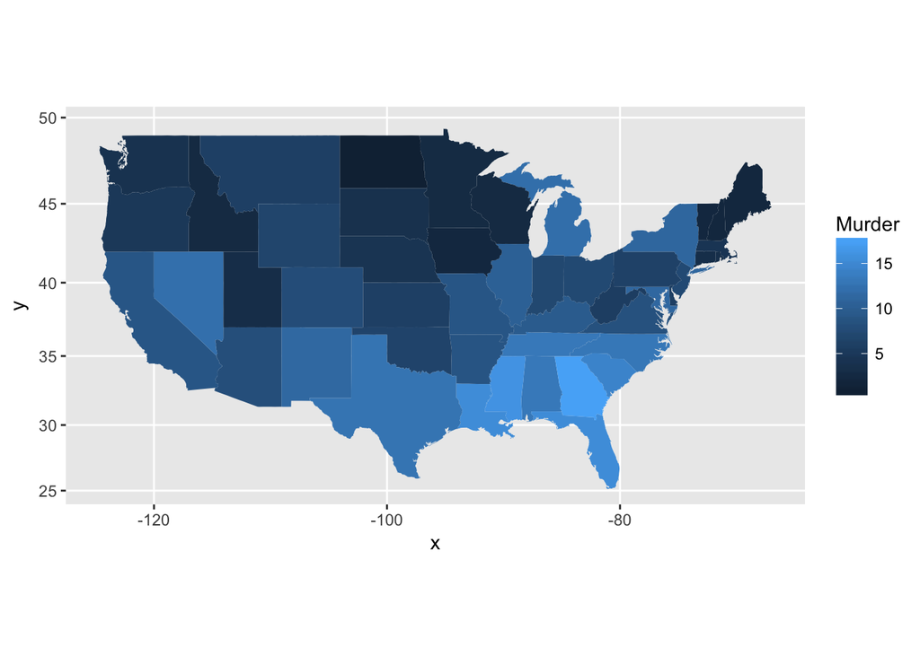

```r
crimes <- data.frame(state = tolower(rownames(USArrests)), USArrests)



states_map <- map_data("state")
map1 <- ggplot(crimes, aes(map_id = state)) + geom_map(aes(fill = Murder), map = states_map) + expand_limits(x = states_map$long, y = states_map$lat)
last_plot() + coord_map()
```

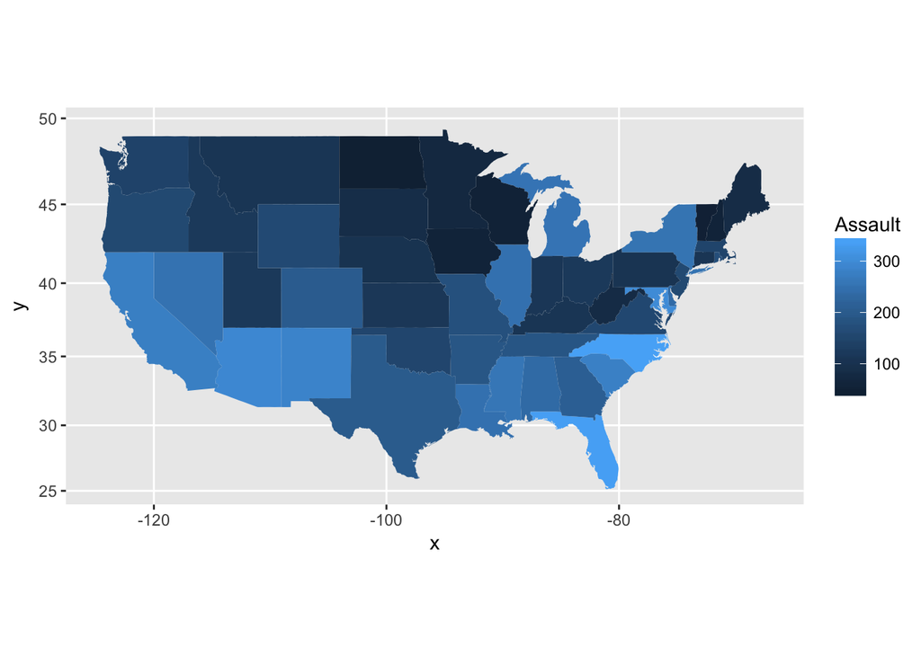

```r
states_map2 <- map_data("state")
map2 <- ggplot(crimes, aes(map_id = state)) + geom_map(aes(fill = Assault), map = states_map2) + expand_limits(x = states_map$long, y = states_map$lat)
last_plot() + coord_map()
```

To see the initial trend we will plot geom_smooth using ‘loess’

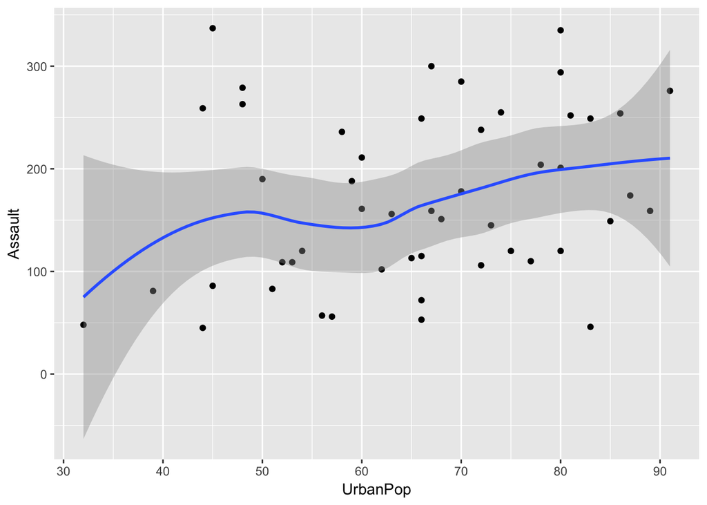

```r
Plot1 <- ggplot(USArrests, mapping = aes(x = UrbanPop, y = Assault)) +
  geom_point()+
  geom_smooth()
Plot1
```

We can view the relationship between Population and Assualt Rates for each state. However I acknowledge that this is a **bad** method since we cannot pinpoint each state. It does demonstrate the power of ggplot!

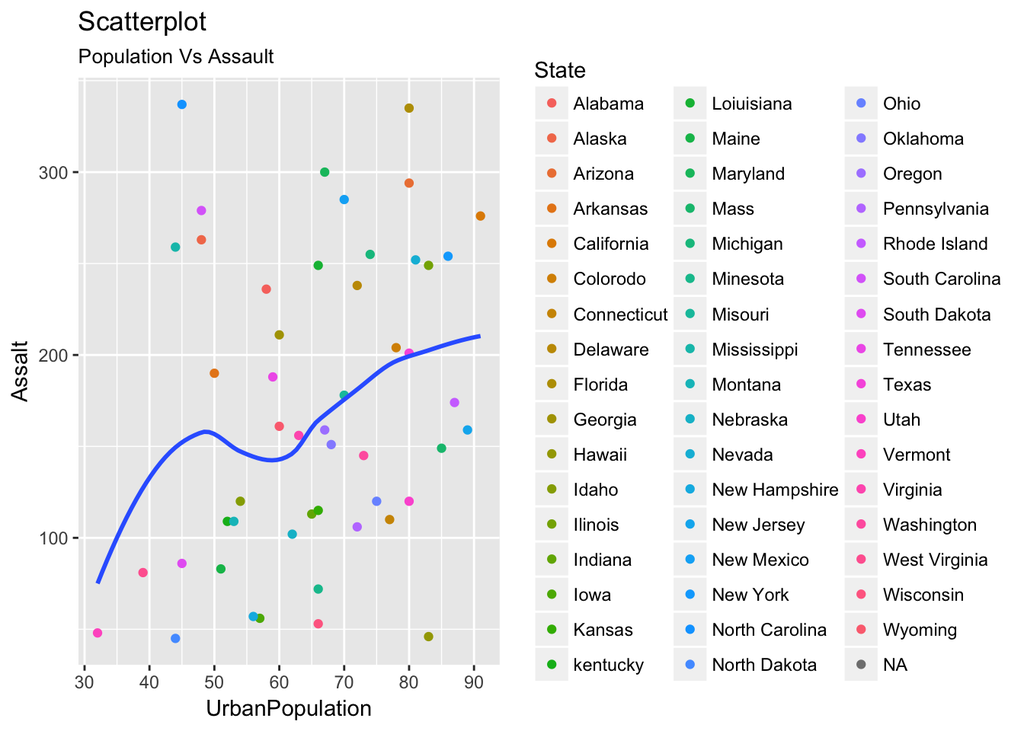

```r
Data <- read_excel("Data.xlsx")

gg <- ggplot(Data, aes(x=UrbanPop, y=Assault)) +
  geom_point(aes(col=State)) +
  geom_smooth(method="loess", se=F) +
  labs(subtitle="Population Vs Assault",
       y="Assalt",
       x="UrbanPopulation",
       title="Scatterplot")

plot(gg)
```

Furthermore we could make each data point a function of Rape levels as well. To do this we map the points to size = Rape.

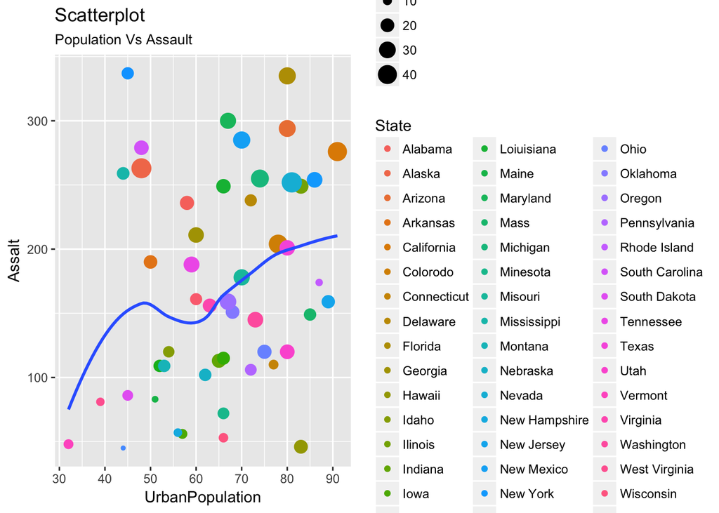

```r
g3 <- ggplot(Data, aes(x=UrbanPop, y=Assault)) +
  geom_point(aes(col=State, size = Rape)) +
  geom_smooth(method="loess", se=F) +
  labs(subtitle="Population Vs Assault",
       y="Assalt",
       x="UrbanPopulation",
       title="Scatterplot")

plot(g3)
```

As we discussed in class, this is information overload! But we have managed to represent four different variables: State, Population, Assault and Rape.

Maybe a simplier way to view these relationships is by using text to represent each point. We can easily change the test size as well. The command “check_overlap = TRUE” is useful to make sure the text does not over lap so it is clearly visible!

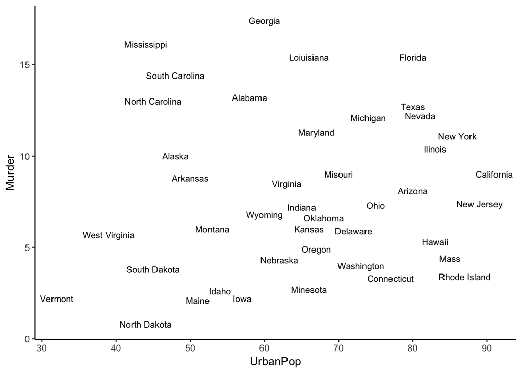

```r
g4 <- ggplot(Data,
       aes(UrbanPop, Murder, label = as.character(State))) + theme_classic() +
  geom_text(check_overlap = TRUE, size = 3)

g4
```

These types of graphs can be manipulated very easily. If we ever wanted to angle the text we simply indicate the angle we want. In this case its a 45 degree angle.

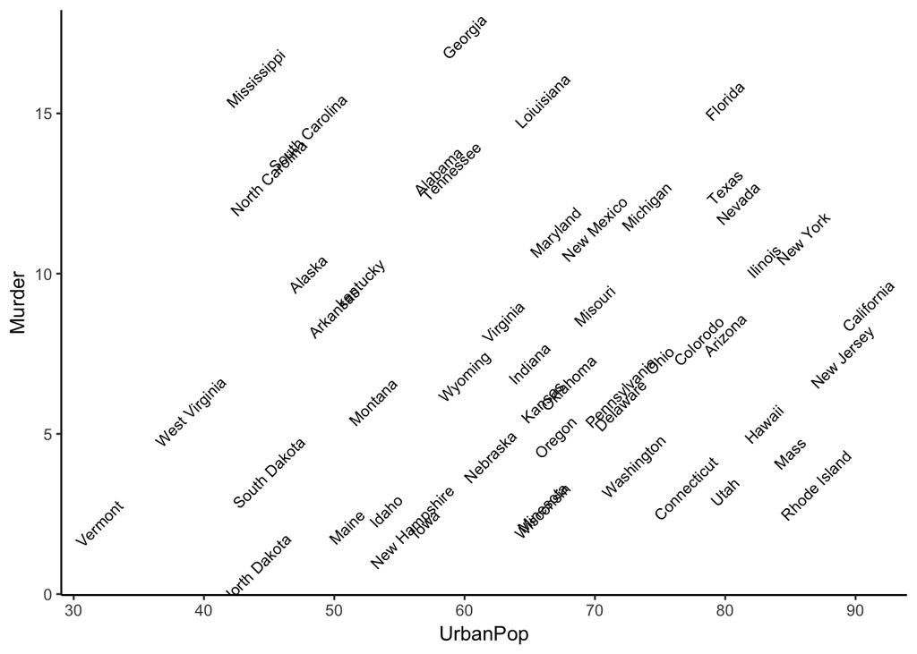

```r
g5 <- ggplot(Data,
             aes(UrbanPop, Murder, label = as.character(State))) + theme_classic() +
  geom_text(angle =45, size = 3)
g5
```

Using ‘Patchwork’ we can combine multiple graphs

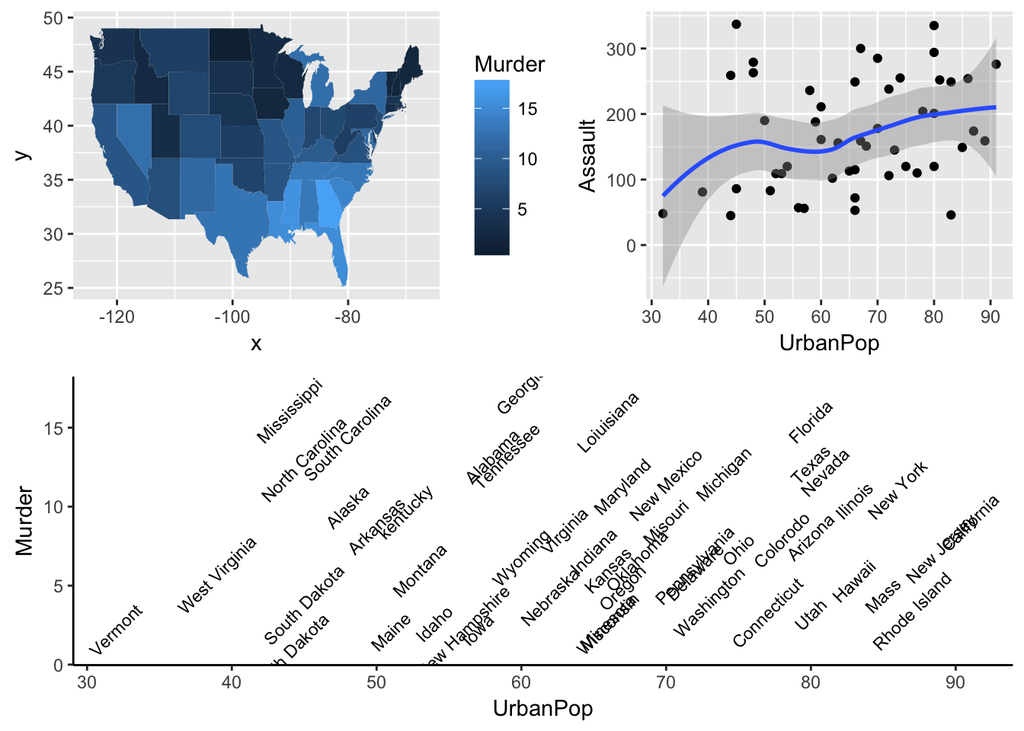

```r
map1 + Plot1 - g5 + plot_layout(ncol = 1)
```